# GAM Analysis: AirQuality Dataset

#### SVM

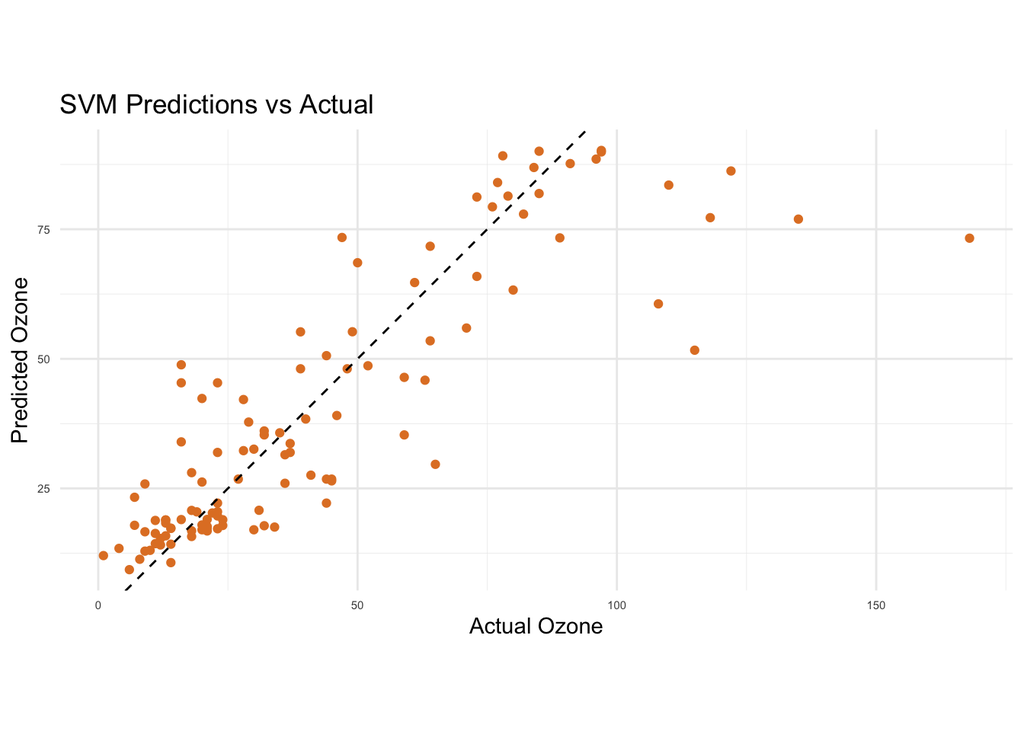

## 5. Fit Interaction Model

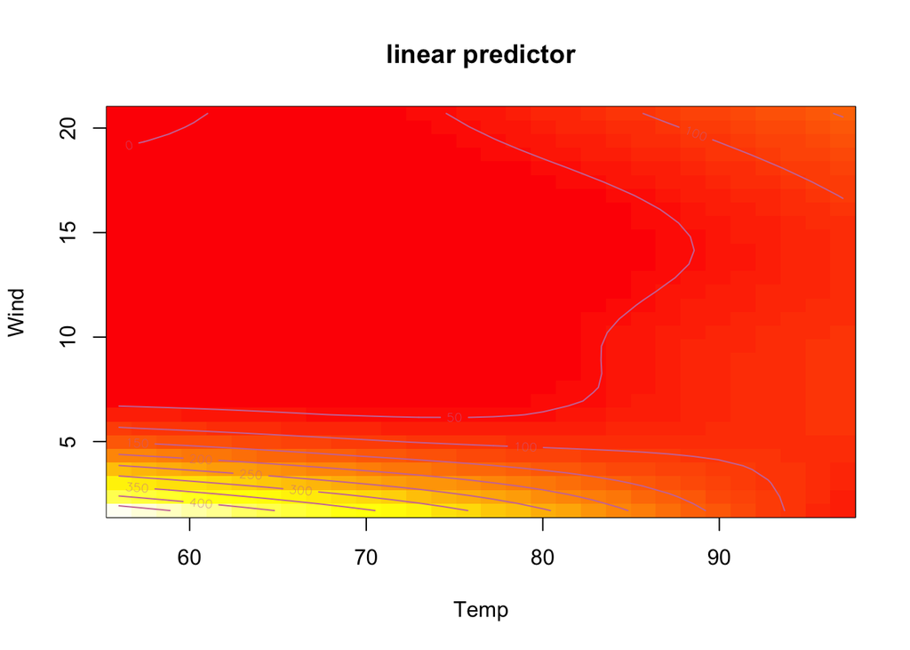

```r
interaction_model <- gam(Ozone ~ te(Temp, Wind), data = airquality)
vis.gam(interaction_model, view=c("Temp", "Wind"), plot.type="contour")
```

## 6. Predict and Visualize Effect of Temperature

We fix `Wind` at its median to isolate the effect of `Temp`.

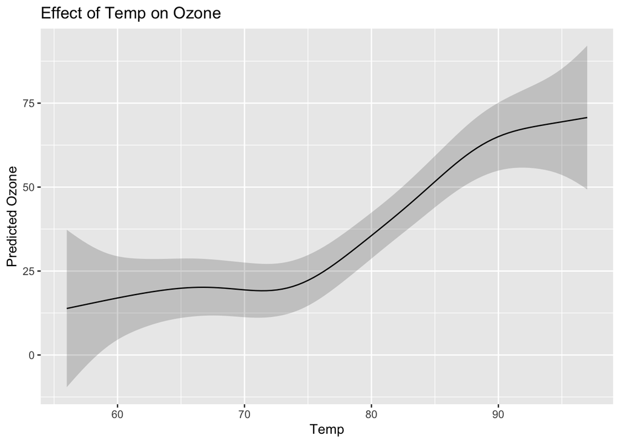

```r
newdata <- data.frame(Temp = seq(min(airquality$Temp), max(airquality$Temp), length=100),
                      Wind = median(airquality$Wind))
preds <- predict(gam_model, newdata = newdata, se.fit = TRUE)

ggplot(newdata, aes(x=Temp, y=preds$fit)) +
  geom_line() +
  geom_ribbon(aes(ymin=preds$fit - 2*preds$se.fit, ymax=preds$fit + 2*preds$se.fit), alpha=0.2) +
  labs(title="Effect of Temp on Ozone", y="Predicted Ozone")
```

## 7. Predict and Visualize Effect of Wind

We fix `Temp` at its median to isolate the effect of `Wind`.

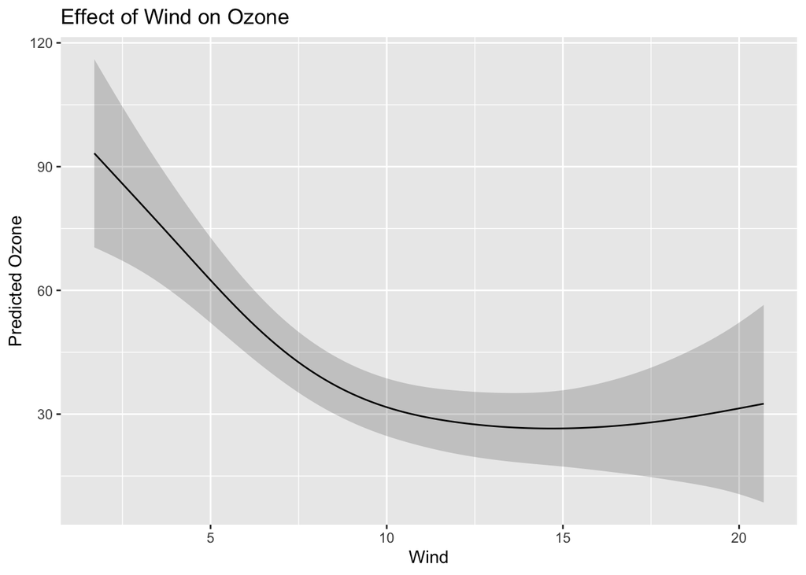

```r
newdata_wind <- data.frame(Wind = seq(min(airquality$Wind), max(airquality$Wind), length=100),
                           Temp = median(airquality$Temp))
preds_wind <- predict(gam_model, newdata = newdata_wind, se.fit = TRUE)

ggplot(newdata_wind, aes(x=Wind, y=preds_wind$fit)) +
  geom_line() +
  geom_ribbon(aes(ymin=preds_wind$fit - 2*preds_wind$se.fit, ymax=preds_wind$fit + 2*preds_wind$se.fit), alpha=0.2) +
  labs(title="Effect of Wind on Ozone", y="Predicted Ozone")
```

## 8. Summary

- GAMs allow flexible modeling of non-linear effects.
- Smoothing penalties prevent overfitting.
- Interactions can be modeled using tensor product splines.
- `mgcv` is the primary R package for GAM modeling.
- This example shows that non-linear and interaction effects are present in air quality data.

## 9. References

- Wood, S. N. (2017). Generalized Additive Models: An Introduction with R.
- Hastie, T., & Tibshirani, R. (1990). Generalized Additive Models.
- Kolmogorov–Arnold representation theorem: foundational result in multivariate function approximation